# Screening of Contaminating features

Yanxian Li

2020-02-03 10:36:45

# Load packages

```r
library(here) # [CRAN] A replacement for 'file.path()', locating the files relative to the project root.
library(tidyverse) # [CRAN] Easily Install and Load the 'Tidyverse'
library(cowplot) # [CRAN] # Streamlined Plot Theme and Plot Annotations for 'ggplot2'
library(ggstatsplot) # [CRAN] # 'ggplot2' Based Plots with Statistical Details

set.seed(1910)
```

# Introduction

The screening will be based on two typical characteristics of Contaminating sequences as outlined in the paper by [Davis et al. (2018)](https://microbiomejournal.biomedcentral.com/articles/10.1186/s40168-018-0605-2): they are likely to have frequencies that inversely correlate with sample DNA concentration and are likely to have higher prevalence in control samples than in true samples. The authors developed an R package, [*decontam*](https://github.com/benjjneb/decontam), for removing Contaminating sequences in the marker-gene and metagenomics data. The package, however, does not make use of positive controls for the identification of Contaminating sequences. As removing of features may heavily affect downstream analyses, we’ll do it by manual screening based on the aforementioned principles.

# Import and tidy data

## Metadata

```r
metadata <- read_tsv(here("data", "metadata.tsv"), comment = "#q2:type") %>%
  rename(SampleID = `#SampleID`)
```

## Feature table

```r
tab <- read_tsv(here("data", "qiime2", "decontam", "table-no-chlo-mito-lowPre-with-phyla-tax-rel.tsv"),
                skip = 1)
tab <- tab %>%
  # sum up features found in the negative and positive controls
  mutate(Ctrl = rowSums(.[grep("EB|LB|M", names(.))], na.rm = TRUE)) %>%
  # remove features not present in the negative or positive controls
  filter(Ctrl > 0) %>%
  # sort features by total relative abundance in the negative and positive controls
  arrange(desc(Ctrl)) %>%
  # remove the newly created variable "Ctrl"
  select(-Ctrl) %>%
  # the following 4 lines of codes transpose the dataframe
  rownames_to_column %>%
  mutate(rowname = factor(rowname, levels = unique(rowname))) %>%
  gather(var, value, -rowname) %>%
  spread(rowname, value) %>%
  # use first row as the column name
  `colnames<-`(.[1, ]) %>%
  # remove the first row
  slice(-1) %>%
  rename(SampleID = `#OTU ID`)
```

Extract the taxonomy and convert to long format

```r
tax <- tab %>%
  filter(SampleID == "taxonomy") %>%
  t() %>%
  data.frame() %>%
  # use first row as the column name
  `colnames<-`(.[1, ]) %>%
  slice(-1) %>%
  # make 80 (number of samples) replicates of each row
  uncount(nrow(tab)-1)
```

## Merge feature table and metadata

```r
tab_merged <- inner_join(metadata, tab, by = "SampleID") %>%
  arrange(match(SampleType, c("REF-DIC", "REF-DIM", "IM-DIC", "IM-DIM",
                              "Blank-library", "Blank-extraction", "Mock"))) %>%
  gather(featureID, abundance, 74:ncol(.)) %>%
  # convert "abundance" to a numeric variable as percentage
  mutate(abundance = as.numeric(abundance), abundance = abundance * 100) %>%
  # add taxonomy after the featureID column
  add_column(tax = tax[, 1], .after = "featureID") %>%
  as.data.frame()
```

Convert featureID, SampleID and SampleType to factors

```r
tab_merged$featureID <- factor(tab_merged$featureID, unique(tab_merged$featureID))

tab_merged$SampleID <- factor(tab_merged$SampleID, unique(tab_merged$SampleID))

tab_merged$SampleType <- factor(tab_merged$SampleType, c("REF-DIC", "REF-DIM", "IM-DIC", "IM-DIM",
                                                         "Blank-library", "Blank-extraction", "Mock"))
```

# Feature prevalence

We’ll use barplot to visualize the abundance and prevalence of the features found in the positive and negative controls.

```r
# Split the dataframe by "featureID"
tab_merged_spl <- split(tab_merged, f = tab_merged$featureID)

# Make barplot for each feature
pdf(here("data", "qiime2", "decontam", "feature_prevalence.pdf"), width = 16, height = 10)

lapply(
  seq_along(tab_merged_spl), # add index to the elements in the list
  function(x)
  {
    # Make bar plots including samples and negative controls
    p1 <- tab_merged_spl[[x]] %>%
      filter(SampleType != "Mock") %>%
      ggplot(aes(x = SampleID, y = abundance, fill = SampleType)) +
        geom_bar(stat = "identity", position = position_dodge()) +
        scale_y_continuous(limits = c(0, NA), expand = expand_scale(mult = c(0, 0.1))) +
        labs(title = unique(tab_merged_spl[[x]][, "tax"]), y = "Relative abundance (%)") +
        scale_fill_brewer(palette = "Dark2", drop = F) +
        guides(fill = guide_legend(nrow = 1)) +
        theme_bw() +
        theme(plot.title = element_text(size = 12),
              axis.title.x = element_text(size = 12),
              axis.text.x = element_text(angle = 45, hjust = 1),
              axis.title.y = element_text(size = 12),
              legend.position = "bottom")

    # Make bar plots including mock only
    p2 <- tab_merged_spl[[x]] %>%
      filter(SampleType == "Mock") %>%
      ggplot(aes(x = SampleID, y = abundance, fill = SampleType)) +
      geom_bar(stat = "identity", position = position_dodge()) +
      scale_y_continuous(limits = c(0, NA), expand = expand_scale(mult = c(0, 0.1))) +
      labs(x = "", y = "") +
      scale_fill_brewer(palette = "Dark2", drop = F) +
      guides(fill = guide_legend(nrow = 1)) +
      theme_bw() +
      theme(axis.text.x = element_text(angle = 45, hjust = 1), legend.position = "bottom")

    # Assemble plots
    plot_grid(p1, p2 + theme(legend.position = "none"), nrow = 1, align = 'h',
              axis = "bt", rel_widths = c(15, 1))
  }
)

dev.off()
```

# Correlation analysis

We’ll use Cq values from the qPCR assays as proxies of microbial DNA concentration in the samples. A clear positive correlation between the feature abundances and Cq values is indicative of contamination.

## Cq values distribution

Before we proceed with correlation analysis, we’ll Check Cq values and see if they make sense. Normally, we expect lower Cq values for gut contents and mock, and higher Cq values for mucosa and negative controls.

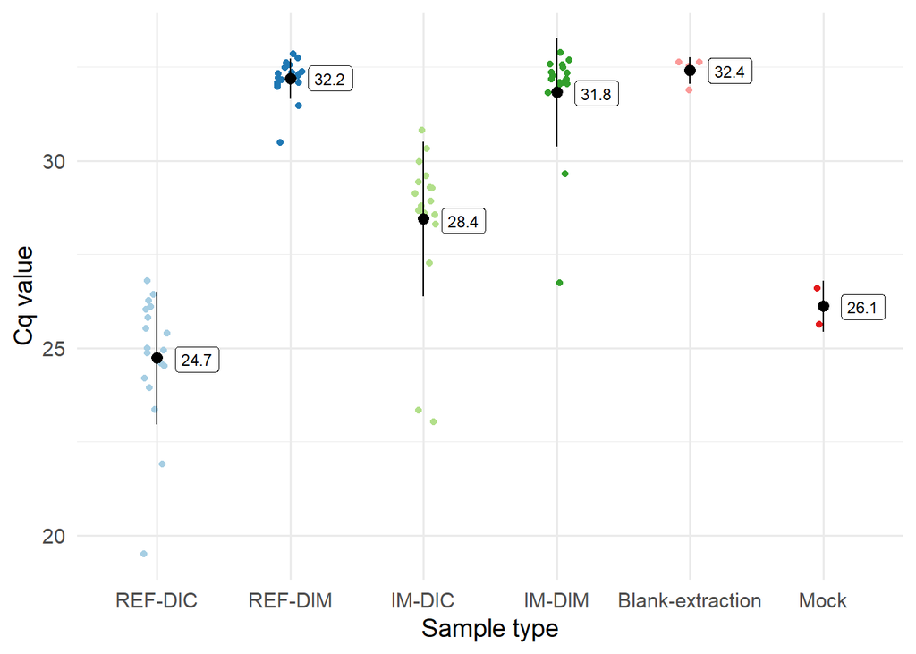

```r
tab_merged %>%
  # get Cq values from one of the features
  filter(featureID == unique(.$featureID)[1]) %>%
  drop_na(qPCRCqValue) %>%
  # calculate mean Cq values for each sample type for text annotation
  group_nest(SampleType) %>%
  mutate(cq_mean = map_dbl(data, ~mean(.x$qPCRCqValue)),
         cq_mean = round(cq_mean, 1)) %>%
  unnest() %>%
  ggplot(aes(x = SampleType, y = qPCRCqValue)) +
  geom_jitter(aes(colour = SampleType), shape = 16, position = position_jitter(0.1)) +
  geom_label(aes(y = cq_mean, label = cq_mean), size = 3, nudge_x = 0.3) +
  # add mean plus/minus 1SD
  stat_summary(fun.data = "mean_sdl", fun.args = list(mult = 1), geom = "pointrange") +
  labs(x = "Sample type", y = "Cq value") +
  scale_colour_brewer(palette = "Paired") +
  theme_minimal(base_size = 14) +
  theme(legend.position = "none")
```

```r
ggsave(here("result", "figures", "Figure S1.tiff"), width = 8, height = 5,
       units = "in", dpi = 300, compression = "lzw")
```

Everything looks normal. We proceed to correlation analysis.

## Correlation analysis

```r
# Exclude samples with zero count of features
tab_merged <- filter(tab_merged, abundance != 0)

# Split the dataframe by featureID
tab_merged_spl <- split(tab_merged, f = tab_merged$featureID)

# Make correlation plots
pdf(here("data", "qiime2", "decontam", "correlation.pdf"), width = 16, height = 12)

lapply(
  seq_along(tab_merged_spl), # add index to elements in the list
  function(x)
  {
    # Extract taxonomy and featureID as title and subtitle, respectively
    main <- ggdraw() + draw_label(unique(tab_merged_spl[[x]]$tax), fontface='bold')

    # Correlation using all samples
    p_all <- tab_merged_spl[[x]]%>%
      ggplot(aes(x = qPCRCqValue, y = abundance)) +
      geom_point(aes(color = SampleType)) +
      geom_smooth(method = "lm") +
      scale_y_continuous(limits = c(0, NA), expand = expand_scale(mult = c(0, 0.1))) +
      labs(x = "Cq value", y = "Relative abundance (%)", title = "Correlation with all samples") +
      scale_fill_brewer(palette = "Dark2") +
      guides(colour = guide_legend(nrow = 1)) +
      theme_bw() +
      theme(plot.title = element_text(size = 14, face = "bold", hjust = 0.5),
            axis.title.x = element_text(size = 12),
            axis.title.y = element_text(size = 12),
            legend.position = "bottom")

    # Corraltion analysis within each sample type
    p_sub <- tab_merged_spl[[x]] %>%
      filter(!SampleType %in% c("Blank-library", "Blank-extraction", "Mock")) %>%
      # make a list column grouped by 'SampleType'
      group_split(SampleType, keep = T) %>%
      map(function(x)
        # turn off stats if the number of observation is less than 6
        if(sum(!is.na(x$abundance)) < 6){
          ggscatterstats(data = x,
                         x = qPCRCqValue,
                         y = abundance,
                         type = "spearman", # type of test that needs to be run
                         conf.level = 0.95, # confidence level
                         xlab = "Cq value", # label for x axis
                         ylab = "Relative abundance (%)", # label for y axis
                         title = paste0("Correlation within the sample type: ", unique(x$SampleType)),
                         k = 3, # no. of decimal places in the results
                         marginal = F, # whether show ggExtra::ggMarginal() plots or not
                         results.subtitle = F, # turn off stats
                         messages = F) # turn off messages and notes
        } else {
          # turn on stats if the number of observation is no less than 6
          ggscatterstats(data = x,
                         x = qPCRCqValue,
                         y = abundance,
                         type = "spearman",
                         conf.level = 0.95,
                         xlab = "Cq value",
                         ylab = "Relative abundance (%)",
                         title = paste0("Correlation within the sample type: ", unique(x$SampleType)),
                         k = 3,
                         marginal = F,
                         messages = F)
        }
      )

    # Assemble plots
    panel_1 <- plot_grid(main, p_all, ncol = 1, rel_heights = c(1, 12))
    panel_2 <- plot_grid(plotlist = p_sub, ncol = 2, rel_heights = c(1, 1))
    plot_grid(panel_1, panel_2, ncol = 1, rel_heights = c(1, 1.2))
  }
)

dev.off()
```

# List of Contaminating sequences

Based on the evaluation of the taxa bar plots, correlation plots and our prior knowledge of common Contaminating taxa found in our lab, the following features are considered as Contaminating sequences in the samples.

```r
contam_sample <- tab_merged %>%
  select(featureID, tax) %>%
  distinct() %>%
  filter(row_number() %in% c(1,2,4,5,6,8,10,11,14,16,18,21,23,26,29,30,32,33,34,35,36,37,38,39,40,42,
                             43,45,46,47,48,50,51,53,54,55,56,58,59,60,62,63,64,66,71,76,88,90,104))
```

The mock, [ZymoBIOMICS D6300](https://www.zymoresearch.com/collections/zymobiomics-microbial-community-standards/products/zymobiomics-microbial-community-standard), comes with a guaranteed impurity level of < 0.01% (by DNA abundance). Therefore, as long as we observe any alien taxa present at > 0.01% in the mock, we can conclude that they are introduced during by the workflow. The following features are considered as Contaminating features in the mock.

```r
contam_mock <- tab_merged %>%
  select(featureID, tax) %>%
  distinct() %>%
  filter(row_number() %in% c(1,6,21,23,26,30,32,33,34,35,36,37,38,39,40,41,42,43,44,45,46,47,48,49,50,51,
                             52,53,54,55,56,58,59,60,61,62,63,64,65,66,67,69,71,73,74,76,85,88,90,91,92))
```

# Export Contaminating sequence IDs

Now we export the featureIDs of Contaminating sequences for feature table filtering.

```r
# Contaminating features for samples (Table S1)
write.table(contam_sample,
            file = here("data", "qiime2", "decontam", "contaminants-sample.tsv"),
            quote = FALSE,
            sep = '\t',
            row.names = FALSE)

# Contaminating features for the mock
write.table(contam_mock,
            file = here("data", "qiime2", "decontam", "contaminants-mock.tsv"),
            quote = FALSE,
            sep = '\t',
            row.names = FALSE)
```